# Simulation Results (500 reps)

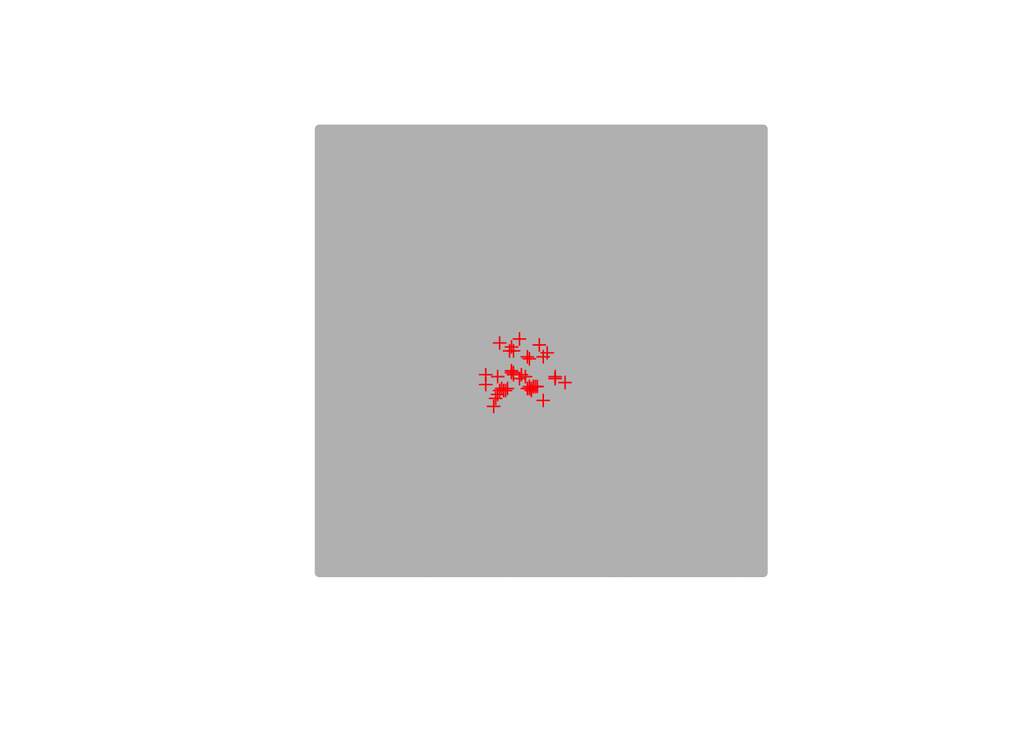

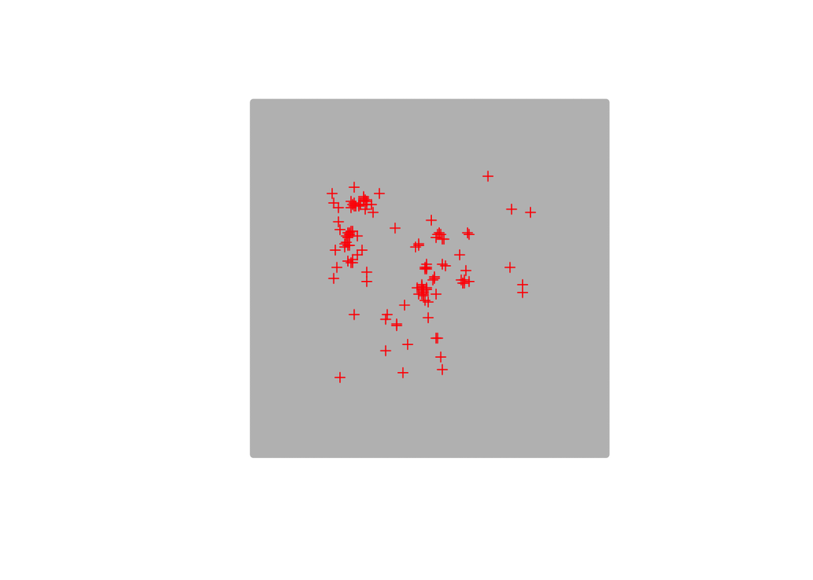

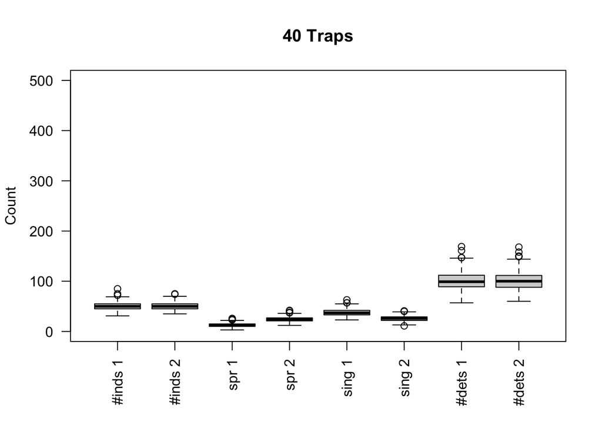

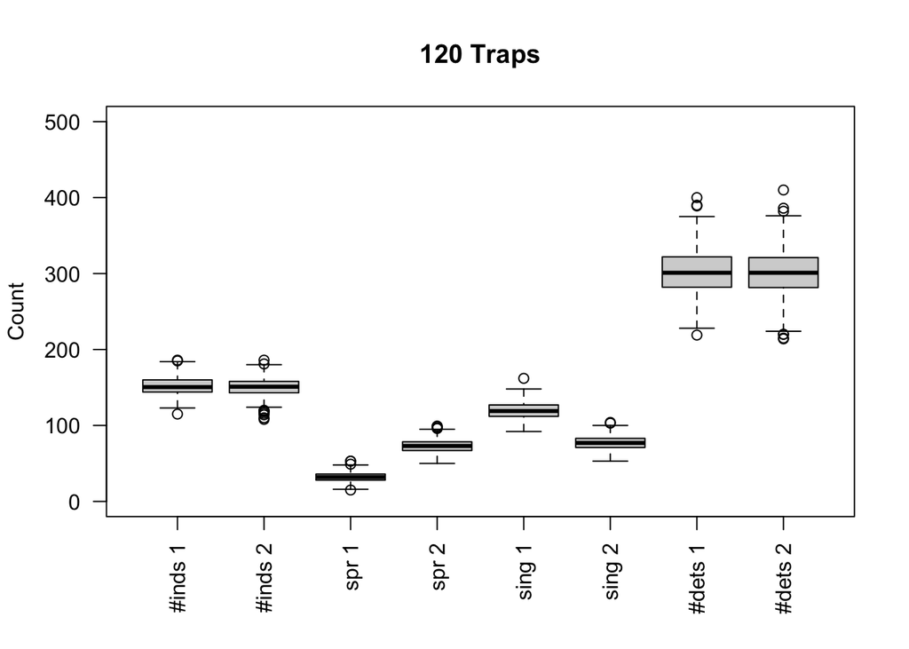

## Simulation Results

Sim Results from GA4 designs (40 traps)

| Values | Strata | D RB | D RSE | L0 RB | L0 RSE | Sigma RB | Sigma RSE | Reps |
| --- | --- | --- | --- | --- | --- | --- | --- | --- |
| S1 | S1 | 4.6 | 0.320 | 0.5 | 0.187 | 1.9 | 0.182 | 499 |
|  | S2 | 11.3 | 0.345 | 0.5 | 0.258 | -0.8 | 0.156 | 499 |
| S2 | S1 | 8.1 | 0.274 | -1.0 | 0.197 | -1.2 | 0.127 | 500 |
|  | S2 | 3.5 | 0.348 | 3.2 | 0.195 | 3.1 | 0.245 | 489 |
| Avg | S1 | 44.0 | 0.687 | -0.8 | 0.204 | -3.8 | 0.274 | 469 |
|  | S2 | 5.6 | 0.229 | 2.4 | 0.279 | 0.0 | 0.142 | 500 |
| Both | S1 | 4.3 | 0.218 | 1.9 | 0.186 | -0.7 | 0.108 | 500 |
|  | S2 | 4.1 | 0.380 | 1.2 | 0.205 | 3.5 | 0.238 | 496 |
| Both (Max) | S1 | 3.0 | 0.222 | -0.8 | 0.185 | 0.7 | 0.185 | 500 |
|  | S2 | 6.2 | 0.396 | 1.2 | 0.189 | 3.8 | 0.189 | 496 |

Sim Results from GA4 designs (120 traps)

| Values | Strata | D RB | D RSE | L0 RB | L0 RSE | Sigma RB | Sigma RSE | Reps |
| --- | --- | --- | --- | --- | --- | --- | --- | --- |
| S1 | S1 | 2.4 | 0.152 | 0.4 | 0.104 | -0.3 | 0.076 | 500 |
|  | S2 | 0.6 | 0.100 | 1.5 | 0.122 | -0.5 | 0.055 | 500 |
| S2 | S1 | 6.8 | 0.226 | 0.4 | 0.116 | -1.6 | 0.109 | 499 |
|  | S2 | 0.5 | 0.100 | 0.9 | 0.109 | -0.6 | 0.053 | 500 |
| Avg | S1 | 14.9 | 0.409 | 1.4 | 0.115 | -2.9 | 0.162 | 496 |
|  | S2 | 0.4 | 0.101 | 0.5 | 0.140 | 0.1 | 0.058 | 500 |
| Both | S1 | 0.6 | 0.143 | 0.1 | 0.112 | 0.3 | 0.075 | 500 |
|  | S2 | 0.2 | 0.097 | 0.5 | 0.108 | -0.3 | 0.051 | 500 |
| Both (Max) | S1 | 1.8 | 0.137 | 0.9 | 0.105 | -0.4 | 0.105 | 500 |
|  | S2 | -0.4 | 0.103 | 1.2 | 0.110 | 0.0 | 0.110 | 500 |

# GA5 Designs (E(n2))

## Realisations and data summaries

**Using S1 values:**

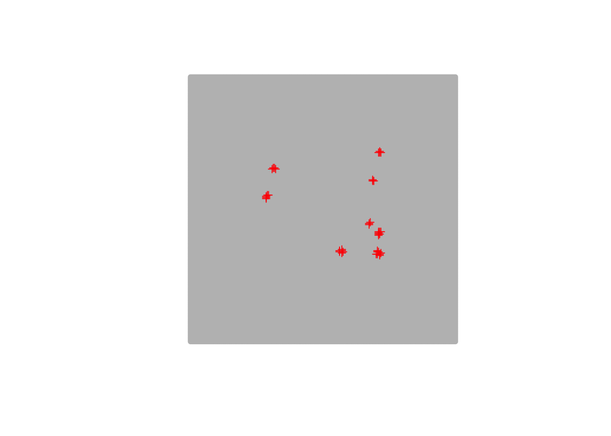

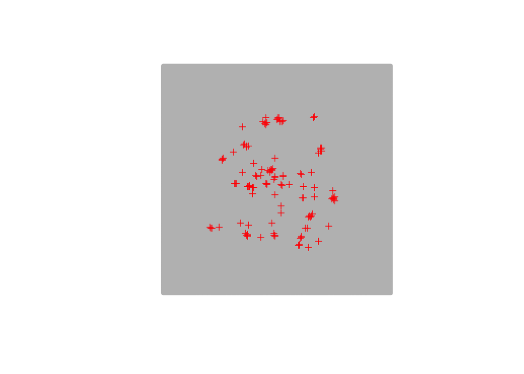

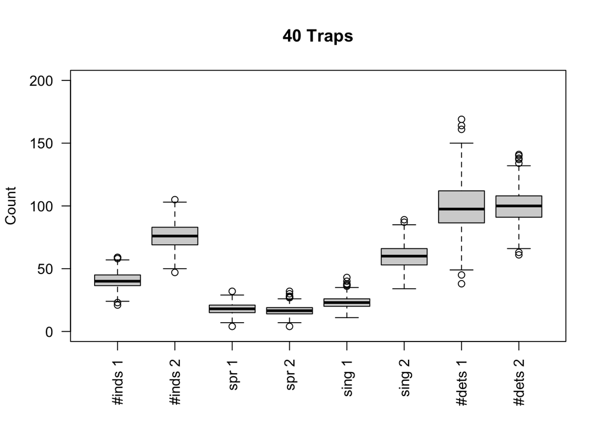

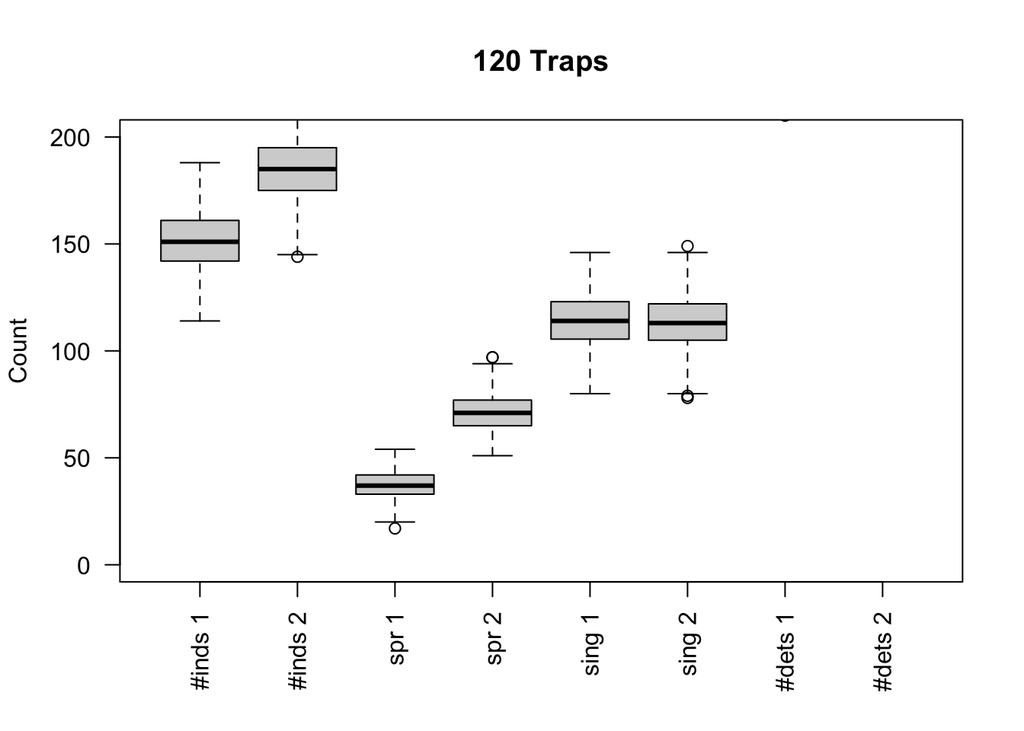

**Using S2 values:**

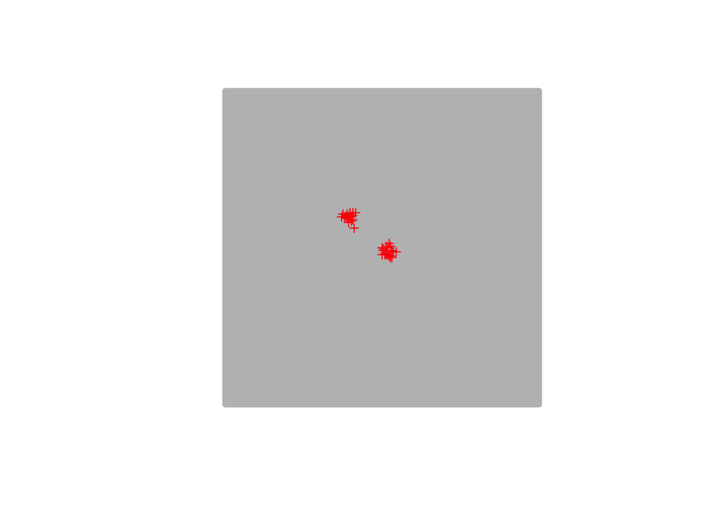

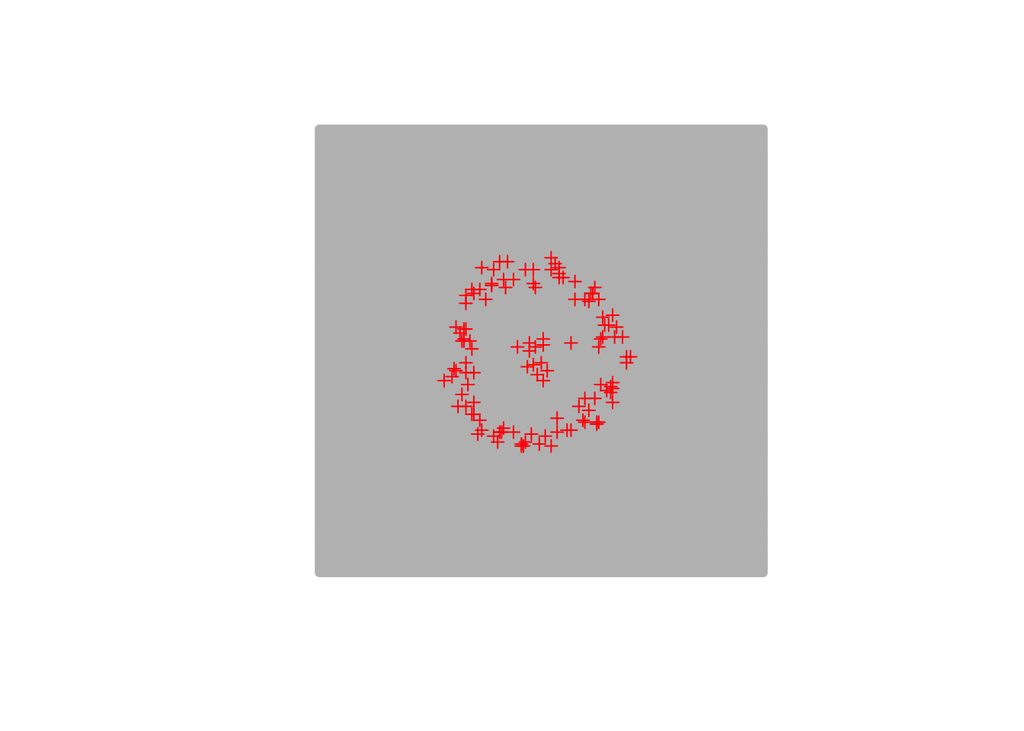

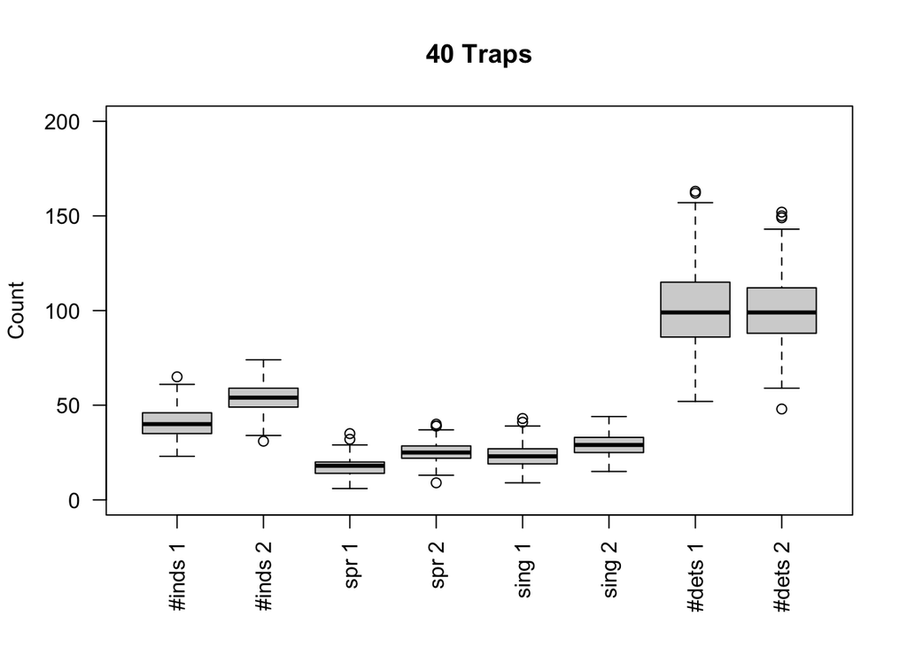

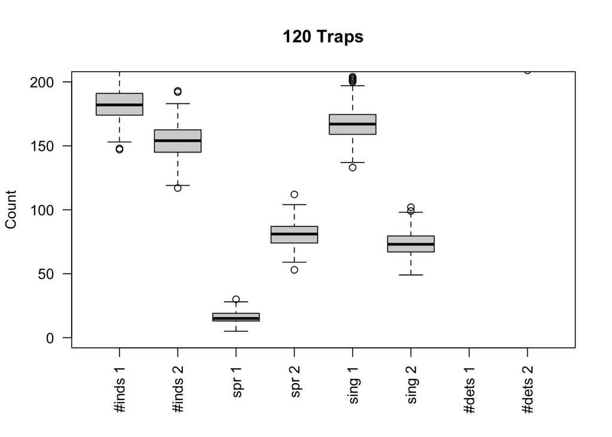

**Using Avg values:**

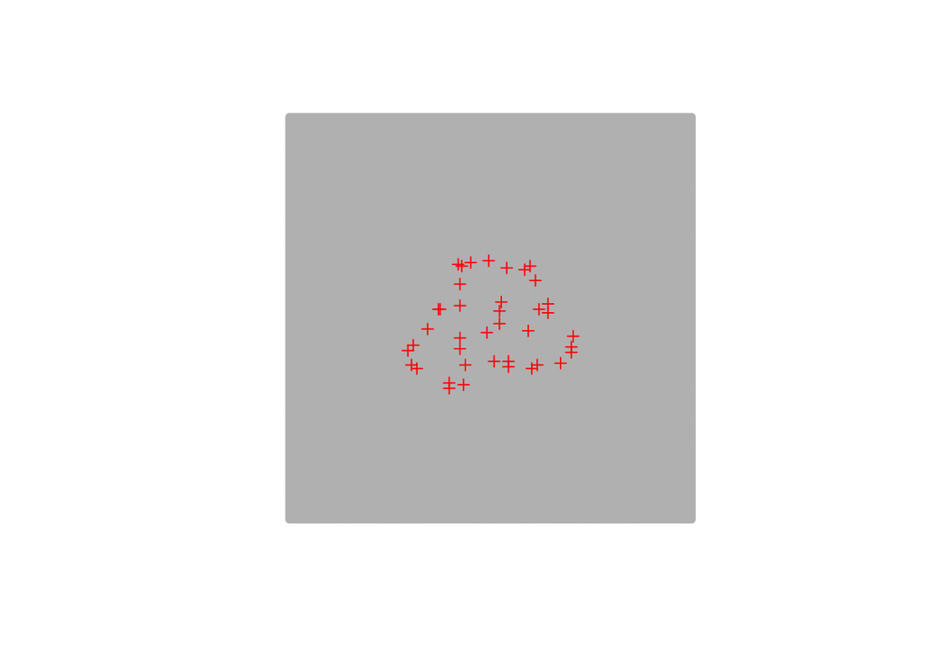

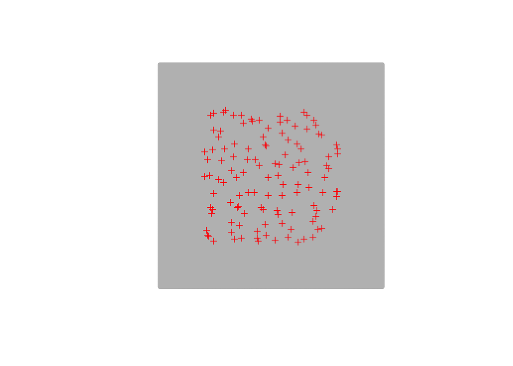

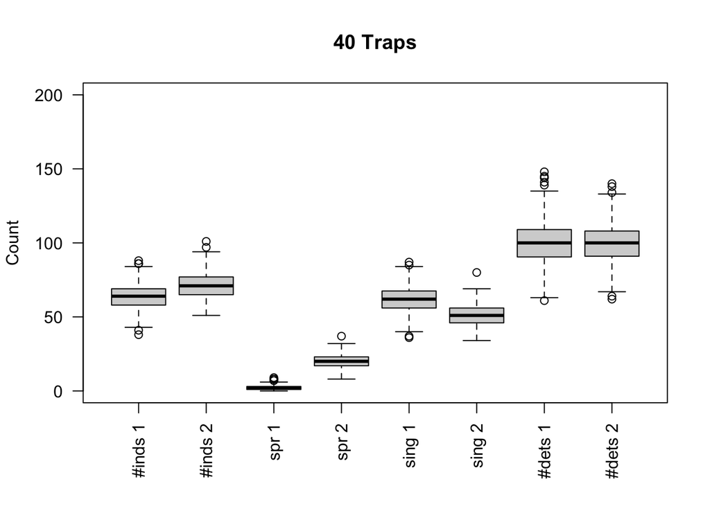

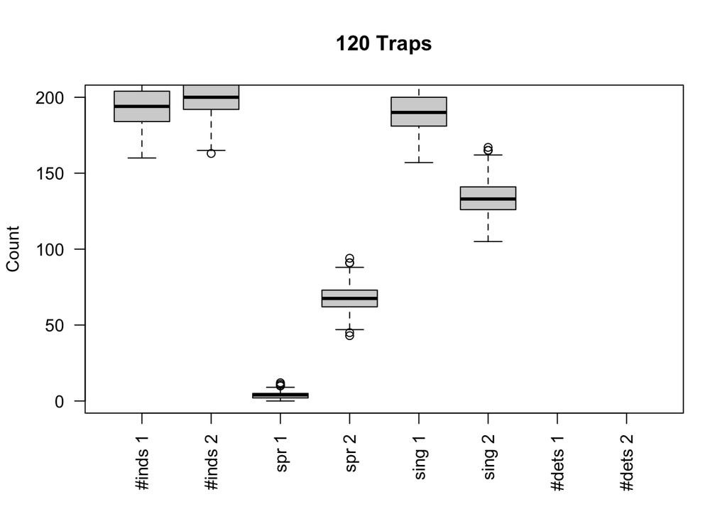

**Using Both values:**

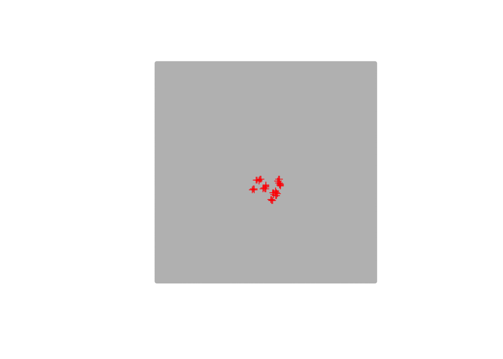

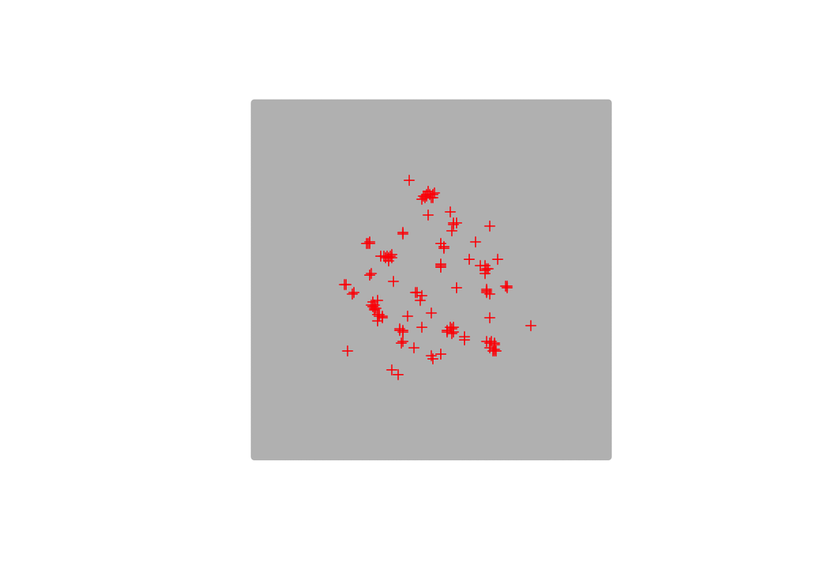

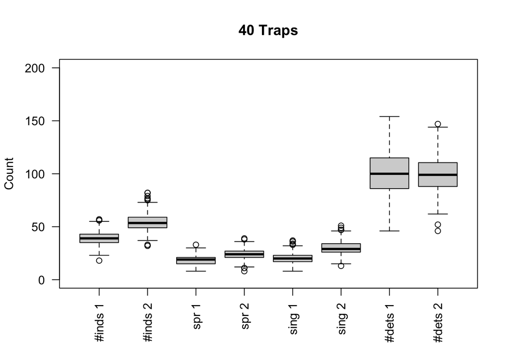

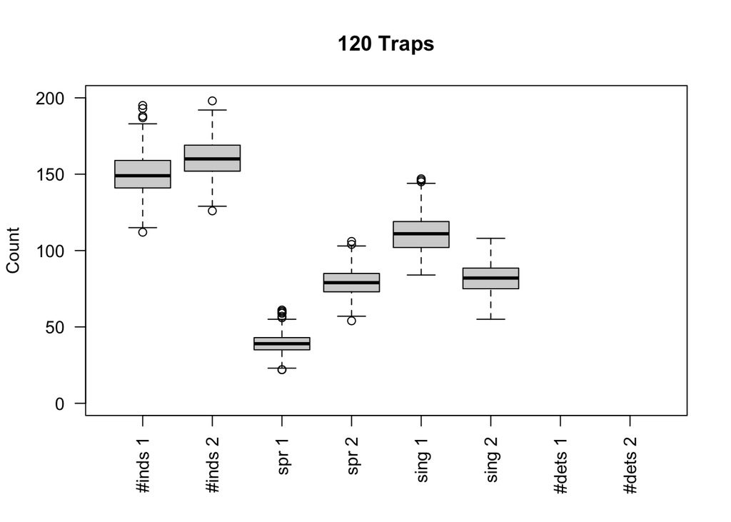

**Using Both (max-min) values:**

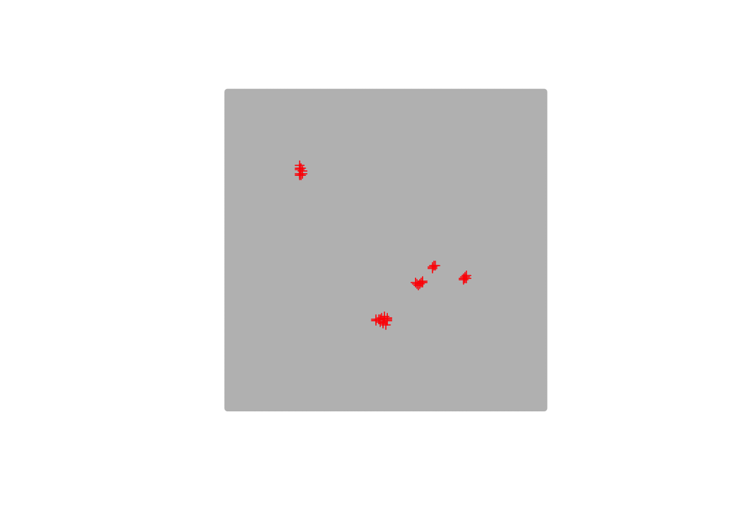

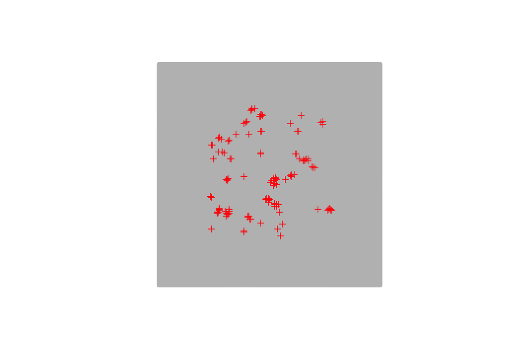

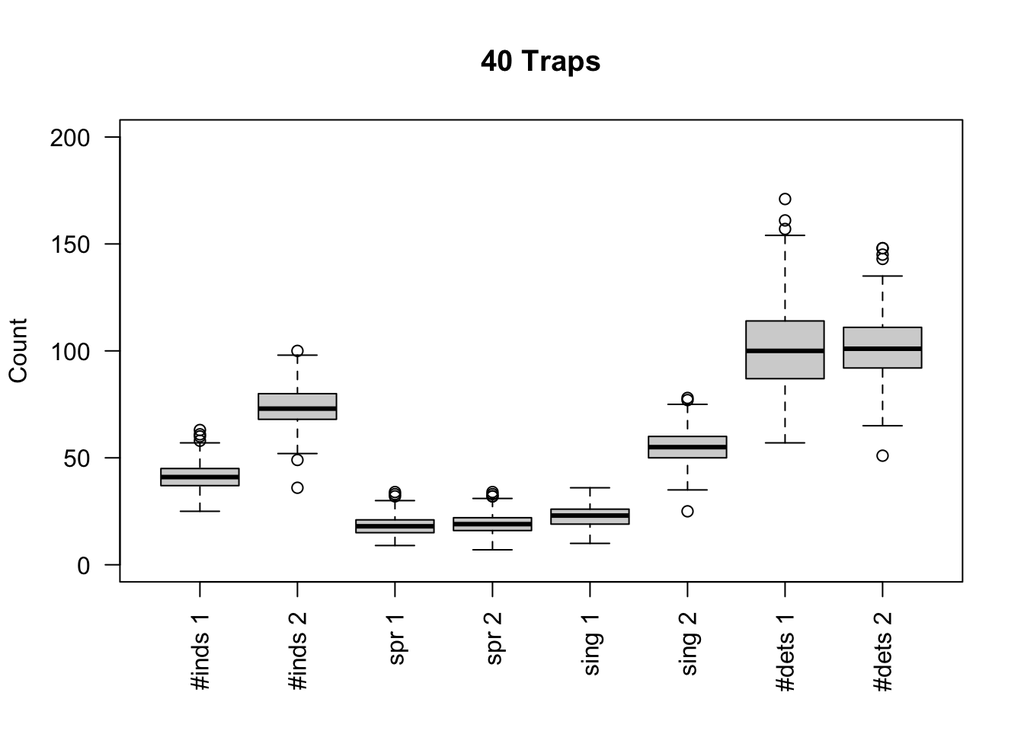

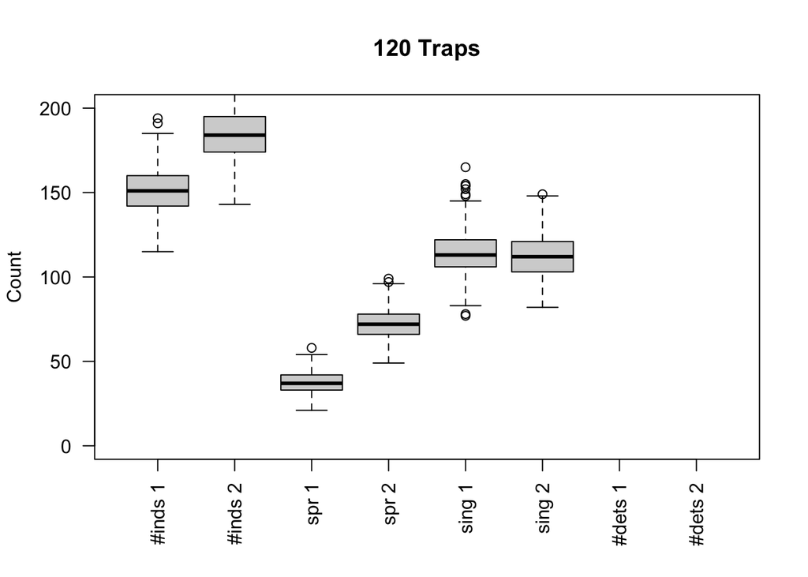

## Simulation Results

Sim Results from GA5 designs (40 traps)

| Values | Strata | D RB | D RSE | L0 RB | L0 RSE | Sigma RB | Sigma RSE | Reps |
| --- | --- | --- | --- | --- | --- | --- | --- | --- |
| S1 | S1 | 3.5 | 0.259 | -0.9 | 0.193 | 0.7 | 0.143 | 500 |
|  | S2 | 13.0 | 0.353 | 2.1 | 0.254 | -2.2 | 0.167 | 498 |
| S2 | S1 | 2.5 | 0.180 | -0.6 | 0.182 | 0.2 | 0.086 | 500 |
|  | S2 | 5.0 | 0.314 | 1.9 | 0.201 | 0.8 | 0.172 | 499 |
| Avg | S1 | 32.6 | 0.573 | -0.6 | 0.203 | -4.5 | 0.228 | 472 |
|  | S2 | 2.0 | 0.200 | 4.2 | 0.252 | -0.5 | 0.131 | 500 |
| Both | S1 | 1.7 | 0.227 | 0.2 | 0.185 | 0.3 | 0.108 | 500 |
|  | S2 | 1.7 | 0.302 | 0.9 | 0.197 | 2.4 | 0.189 | 498 |
| Both (Max) | S1 | 3.9 | 0.260 | 0.2 | 0.186 | 0.7 | 0.186 | 499 |
|  | S2 | 8.7 | 0.283 | 2.0 | 0.245 | -0.6 | 0.245 | 500 |

Sim Results from GA5 designs (120 traps)

| Values | Strata | D RB | D RSE | L0 RB | L0 RSE | Sigma RB | Sigma RSE | Reps |
| --- | --- | --- | --- | --- | --- | --- | --- | --- |
| S1 | S1 | 1.4 | 0.160 | 0.5 | 0.114 | 0.1 | 0.086 | 500 |
|  | S2 | 0.8 | 0.104 | 0.8 | 0.126 | -0.1 | 0.058 | 500 |
| S2 | S1 | 3.1 | 0.166 | 0.1 | 0.109 | -0.3 | 0.084 | 500 |
|  | S2 | 0.5 | 0.102 | 0.3 | 0.111 | 0.1 | 0.053 | 500 |
| Avg | S1 | 20.4 | 0.479 | -0.2 | 0.124 | -3.4 | 0.176 | 497 |
|  | S2 | -0.1 | 0.091 | 1.0 | 0.139 | 0.0 | 0.057 | 500 |
| Both | S1 | 2.2 | 0.146 | 0.7 | 0.111 | -0.3 | 0.075 | 500 |
|  | S2 | 0.5 | 0.093 | 0.9 | 0.113 | -0.1 | 0.053 | 500 |
| Both (Max) | S1 | 1.6 | 0.156 | -0.2 | 0.108 | 0.1 | 0.108 | 500 |
|  | S2 | 1.1 | 0.102 | -0.1 | 0.124 | 0.1 | 0.124 | 500 |

# Lacework

## Design (fixed) and data summaries

**40 Traps**

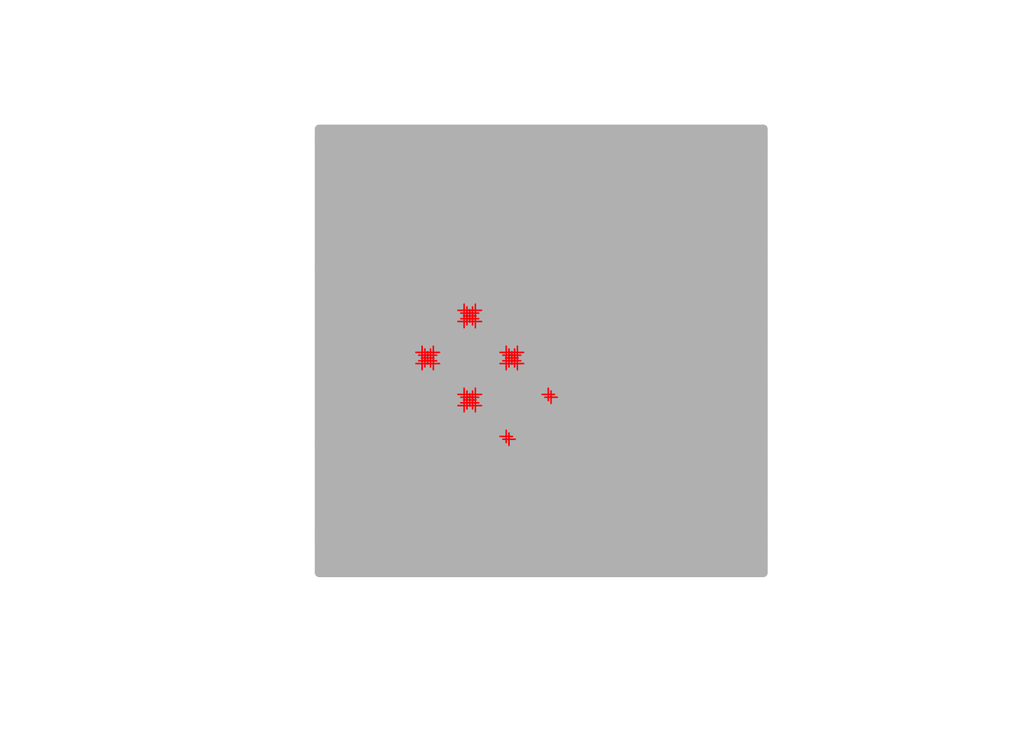

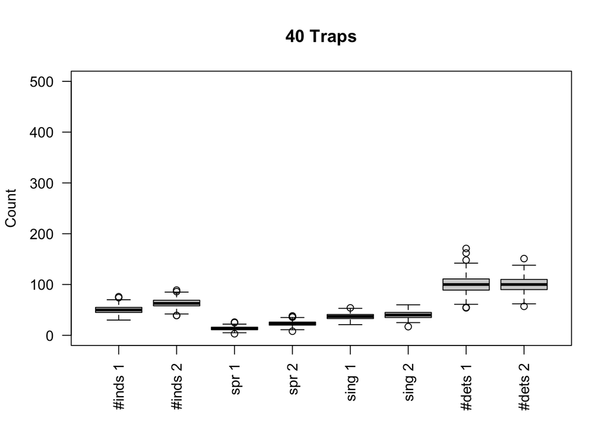

**120 Traps**

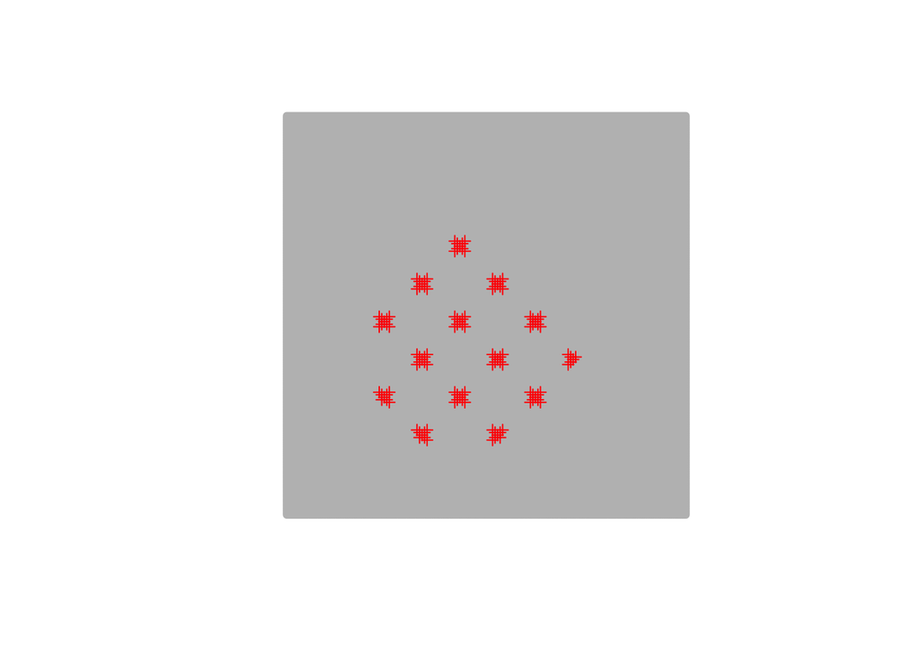

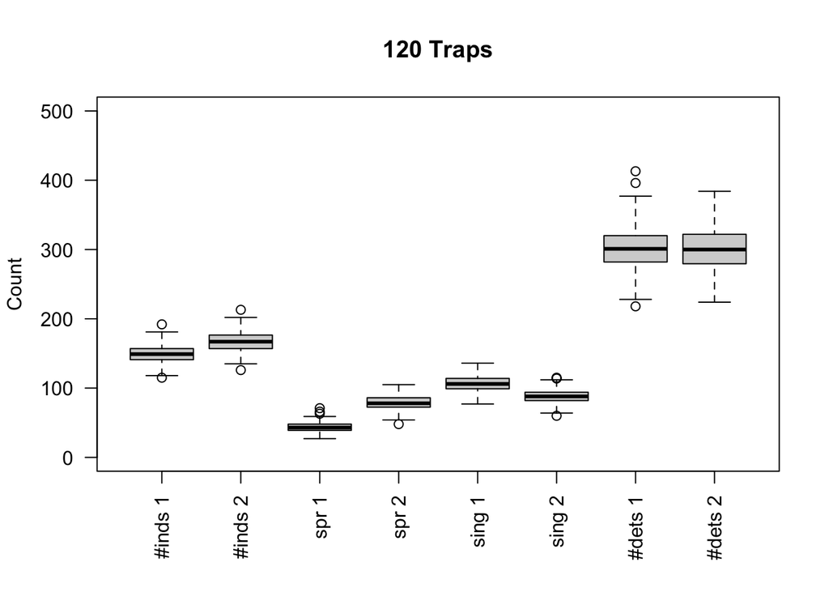

## Simulation Results

Sim Results from lacework design (40 traps)

| Strata | D RB | D RSE | L0 RB | L0 RSE | Sigma RB | Sigma RSE | Reps |
| --- | --- | --- | --- | --- | --- | --- | --- |
| S1 | 2.7 | 0.181 | 2.0 | 0.188 | -1 | 0.096 | 500 |
| S2 | 2.6 | 0.231 | 1.5 | 0.221 | 1 | 0.151 | 500 |

Sim Results from lacework design (120 traps)

| Strata | D RB | D RSE | L0 RB | L0 RSE | Sigma RB | Sigma RSE | Reps |
| --- | --- | --- | --- | --- | --- | --- | --- |
| S1 | 0.2 | 0.102 | 0.2 | 0.110 | 0.4 | 0.054 | 500 |
| S2 | 0.2 | 0.097 | -0.1 | 0.117 | 0.3 | 0.053 | 500 |

# General comments:

## Grid design

- With 40 traps, the grids do not work particularly well
- Spacing of 800 m produces positive bias in D for both strata with a high RSE for strata 2. There was also a high proportion of reps that were excluded for strata 2 (17.2%, and 2.6% for strata 1).
- Slightly reduced spacing of 700 m leads to better performance for S1
- Using 120 traps resolves these issues, I think because the low number of spatial recaps for S1 triple

## Clustered designs

- Using optimal spacing (for 2 groups) works fairly well though there is some bias for S2 and a small proporiton of reps were excluded (3.6%)
- Using 2 sigma spacing results in a slightly more balanced performance across the strata. For 40 traps the 2 $\sigma$ clustered design has lower variance for S2 compared to both GA approaches
- Again using 120 traps resolves any performance issues, and for 2 $\sigma$ spacing there is only space for 64 traps

## GA4 (min(n,r))

- With 40 traps, the behaviour of the GA4 algorithm seems to spread traps much further when using S1 or avg values. I think this is due to the fairly high L0 values that make it easier to get high r so the algorithm spreads traps to increase n. The other settings produce a fairly dense array with traps tending to be quite close together.
- There is some positive bias for S2 when using S1 values and vica versa. This pattern largely disappears with 120 traps though there is still slight positive bias for S1 if using S2 values.
- Using average values results in high positive bias in D for strata 1 with a high RSE and an exclusion rate of 6.2%. This bias reduces quite a lot with 120 traps.
- The best option appears to be using both sets of values which results in essentially unbiased performance, and there is very little difference between a 50-50 weighting and the max-min approach.

## GA5 (min En2)

- The behaviour of the GA5 algorithm consistently produces clusters of traps when there are 40 traps, except when using average values. This pattern is less apparent with 120 traps, except when using both sets of values. The both with max-min option tends to produce clusters that are more spread out compared to without max-min, and appear similar to when using S1 values.
- Using S1 values leads to positive bias in D for S2 but not the other way round. This is not evident with 120 traps.
- Using avg values again leads to high bias and variance in S1 (for both 40 and 120 traps) with an exclusion rate of 5.6% with 40 traps.
- Using both sets of values works well and for 40 traps there seems to be slightly better performance using the 50-50 split over max-min.
- GA5 seems marginally better than GA4 with slightly lower and better balance across the strata in RSE’s in D

## Lacework

- The lacework designs seem to work well and produce balanced performance across the strata
- not suprising that is similar to the clustered designs